# Homework 2

Sidney Gerst

January 27, 2020

#### 1. Analyze the Model

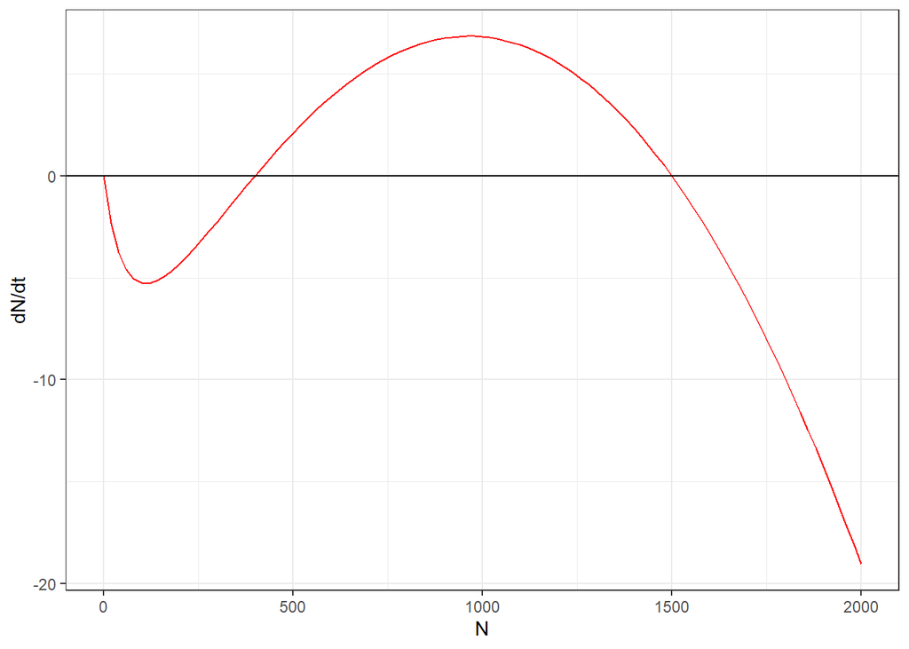

```r
#create the model
r <- 0.05
K <- 2000
P <- 4
a <- 0.05
h <- 0.2
function1 <- function(N) (r*N)*(1-(N/K))-((P*a*N)/(1+(a*h*N)))

#plot it
function1_plot <- ggplot(data.frame(N = 0:2000), aes(x = N)) +
  stat_function(fun = function1, color = "red") +
  geom_hline(yintercept = 0) +
  theme_bw()+
  ylab("dN/dt")

function1_plot
```

#### 3. Equilibrium at N = 0

When N = 0, the intrinsic population growth rate $\frac{dN}{dt}$ = 0, and is a equililbium.

To evaluate N at equilibium, the derivative should be calculated:

$\frac{df(N)}{dN} = r(1-\frac{2N}{K}) - P(\frac{a}{(1 + ahN)^2})$

When N = 0, the equation becomes: $\frac{df(N)}{dN} = r-P*a$

Then we solve for P: $P = \frac{r}{a}$ . Hunters = the growth rate per prey attack rate. P needs to be greather than this number.

When P is larger than $\frac{r}{a}$, the equilibrium is locally stable.

The number of hunters needs to be larger than the intrinsic growth rate over per prey attack rate (or the rate hunters are able to kill the species) in order to eliminate the invasive species. Or the hunters and their attack rate needs to be greater than the intrinsic growth rate.

#### 4. Non-zero equilibria

$0 = r*N*(1-\frac{N}{k})-P*(\frac{aN}{1 + ahN})$

#### 5. Graph model

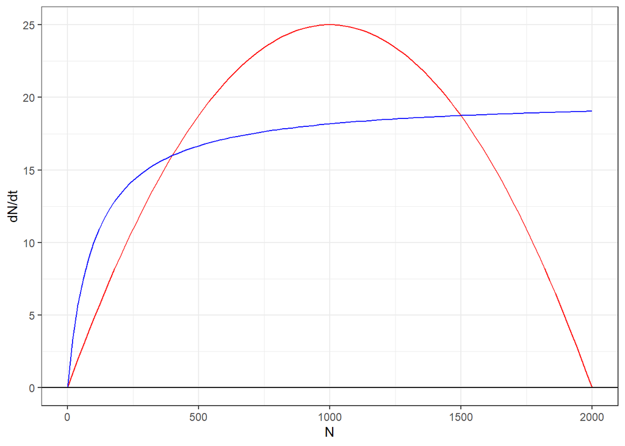

```r
r <- 0.05
K <- 2000
P <- 4
a <- 0.05
h <- 0.2

function2 <- function(N) (r*N)*(1-(N/K))
function3 <- function(N) ((P*a*N)/(1+(a*h*N)))

function2_plot <- ggplot(data.frame(N = 0:2000), aes(x = N)) +
  stat_function(fun = function2, color = "red") +
  stat_function(fun = function3, color = "blue") +
  geom_hline(yintercept = 0) +
  theme_bw()+
  ylab("dN/dt")

function2_plot
```

When the intrinsic growth rate is greater than the hunting rate, the population will continue to grow. When the hunting rate is greater than the intrinsic growth rate, the population will go down to 0. When they are equal, the population will be at equilibrium.

All three equilibrium points are at the same N values as in Problem 1.

#### 6. Graphs of different hunting rates

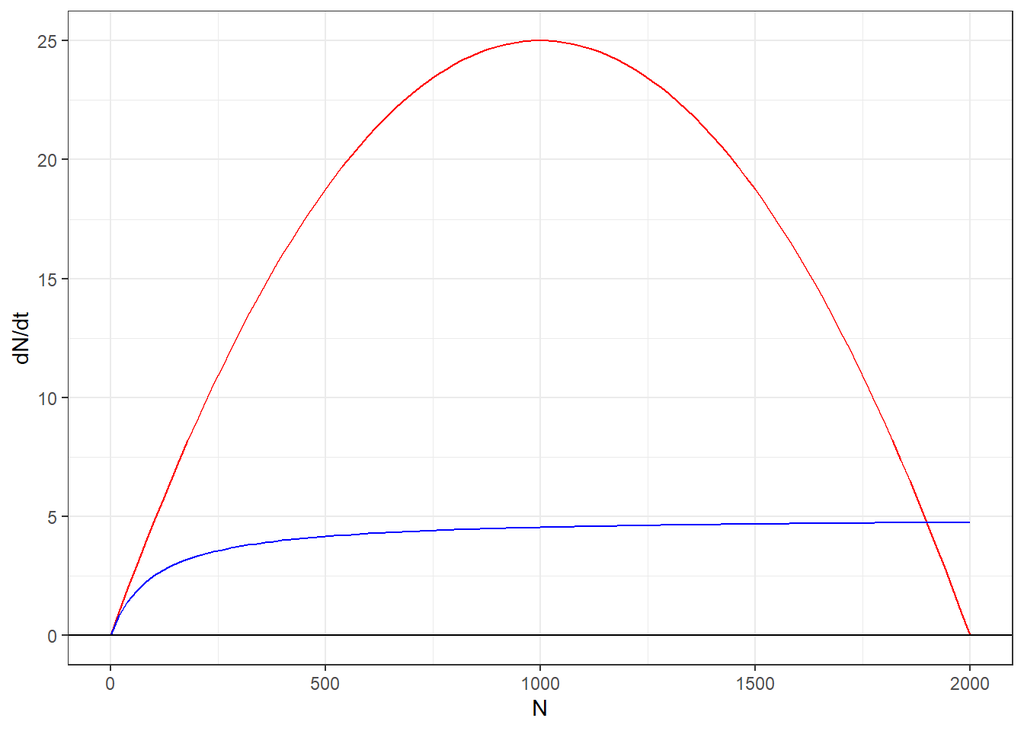

```r
########## P = 1
r <- 0.05
K <- 2000
P <- 1
a <- 0.05
h <- 0.2

function4 <- function(N) (r*N)*(1-(N/K))
function5 <- function(N) ((P*a*N)/(1+(a*h*N)))

function3_plot <- ggplot(data.frame(N = 0:2000), aes(x = N)) +
  stat_function(fun = function4, color = "red") +
  stat_function(fun = function5, color = "blue") +
  geom_hline(yintercept = 0) +
  theme_bw()+
  ylab("dN/dt")

function3_plot
```

There are two equilibria. An unstable equilibrium at N = 0, and a stable at N ~ 1900.

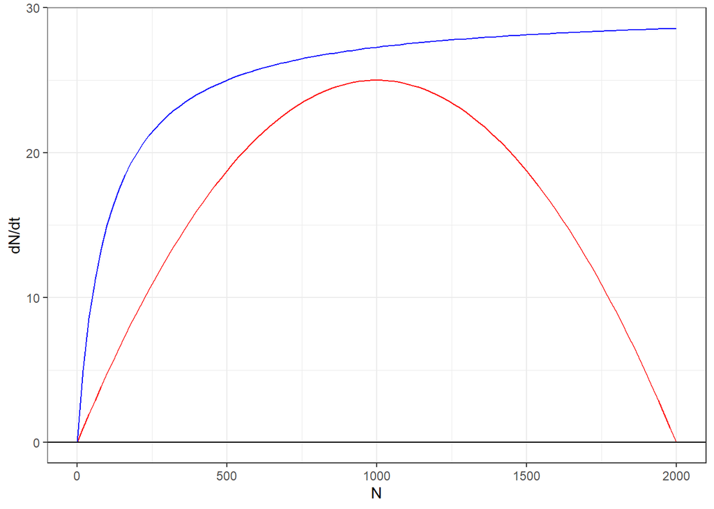

```r
############ P = 6

r <- 0.05
K <- 2000
P <- 6
a <- 0.05
h <- 0.2

function6 <- function(N) (r*N)*(1-(N/K))
function7 <- function(N) ((P*a*N)/(1+(a*h*N)))

function4_plot <- ggplot(data.frame(N = 0:2000), aes(x = N)) +
  stat_function(fun = function6, color = "red") +
  stat_function(fun = function7, color = "blue") +
  geom_hline(yintercept = 0) +
  theme_bw()+
  ylab("dN/dt")

function4_plot
```

There is only one equilibrium at N = 0 and it is stable.

#### 7. Bistability

The domain of attraction for the zero equilibrium goes from 0 - 400. The domain of attraction for the largest equlibrium is any number greater than 400.

The hunting rate is greater than the intrinsic growth rate, so you would be able to extirpate the invasive species.

When the population is at the carrying capacity and the harvest rate is greater, the population will come back to about 1500 individuals.

#### 8. Derivatives

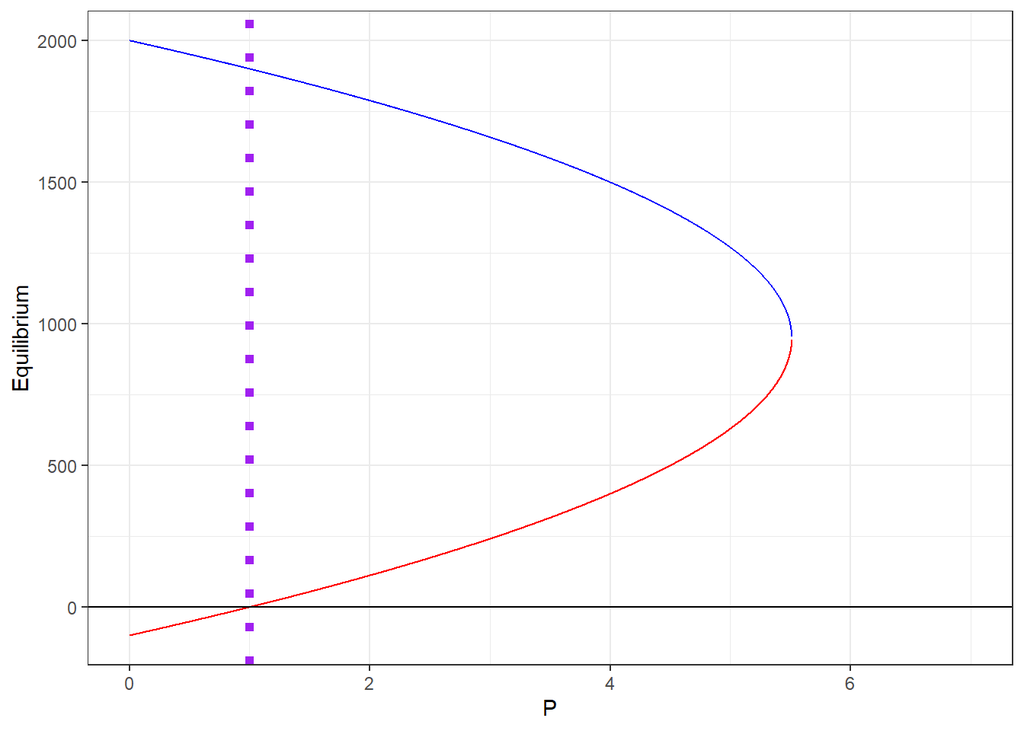

```r
r <- 0.05
K <- 2000
a <- 0.05
h <- 0.2
d <- 1/(a*h)

function8 <- function(P) (1/2) * ((K - d) - sqrt((K-d)^2 + ((4*K*d)/(r)) * (r - a * P)))

function9 <- function(P) (1/2) * ((K - d) + sqrt((K-d)^2 + ((4*K*d)/(r)) * (r - a * P)))

function_8_9_plot <-ggplot(data.frame(P = 0:7) , aes(x = P)) +
stat_function(fun = function8, color = "red", n = 10000) +
  stat_function(fun = function9, color = "blue", n = 10000) +
  geom_hline(yintercept = 0) +
  geom_vline(xintercept = 1, linetype = "dotted", color = "purple", size = 2) +
  theme_bw() +
  ylab("Equilibrium")

function_8_9_plot
```

The equilibium changes from locally stable to locally unstable at P = 1. When there is less than one hunter the equilibrium is negative.